# Applying Text Analysis to Twitter data usig R

Goncalo Veiga

# 1 Loading packages

First, we’re going to make sure we have all the necessary packages installed and loaded in our system.

## 1.1 Pacman::p_load()

The `pacman::p_load()` function checks if a particular package is already installed in our library. If not, `p_load()` will install and load it. This function is especially useful when we use different computers or we share our `.rmd` files with colleagues as it helps setting up the session.

```r
install.packages("pacman")
```

```r
library(pacman)
```

## 1.2 Installing the development version of `stringr`

Due to the fact we will be using some functions that are not in the version available on `CRAN`, we will be installing the development version of the `stringr` package, directly from the authors’ github page.

```r
# Check to see if we have the devtools package installed and loaded
pacman::p_load(devtools)

# Install stringr
devtools::install_github("tidyverse/stringr")
```

## 1.3 Load the necessary packages

Load the packages we will be using for our analysis.

```r
pacman::p_load(# to download twitter data
               rtweet,

               # to import and save our data
               readr,

               # to shape and transform our data
               dplyr,
               forcats,

               # to manipulate strings
               stringi,
               stringr,
               rebus,
               qdapRegex,

               # to extract our lexicons for sentiment analysis
               textdata,

               # to perform sentiment analysis and topic modeling
               tidytext,

               # to plot our visuals
               wordcloud,
               ggplot2)
```

# 2 Importing data

## 2.1 Importing using rtweet

### 2.1.1 Authorize rtweet

We will capture twitter data using the `rtweet` package, which requires us to have an account in the platform. The first time we run the `rtweet::search_tweets()` or `search_tweets2()` functions, we will be prompted to grant permission to the package to use our Twitter credentials. The default browser on our OS will automatically open and ask for our username and password.

[figure not shown]

Figure 1: Authorizing `rtweet` with our account credentials

Upon signing in successfully, we will receive a confirmation that we have completed our authentication process.

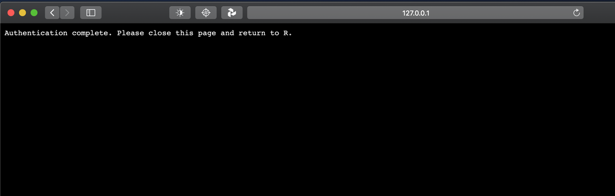

Figure 2: Authentication complete notification

### 2.1.2 Search terms

If we are interested in what people are *saying* about a particular subject or set of subjects, we need to select a set of keywords that will be used to find the relevant tweets.

Let us consider that we want to know how working people are experiencing the pandemic: we might be interested in how they are coping at work with the different restrictions in place, their experience of working from home, job hunting, being laid-off or fired, or their perception of how political leaders are handling the economy. We need to decide which terms will best capture work posts that are pandemic-related.

We can tentatively consider that the terms *work* and *job* are good keyword candidates for the task. However, since we are particularly interested in statements that take the pandemic into account, we will be using additional terms that will help narrow down our search. We can achieve that by including the terms *covid*, *coranavirus* and *pandemic* to a secondary search query in the same argument. Our goal is to collect posts that have at least one term from these two combined queries, such as *covid* and *work*, *pandemic* and *job*, or *covid* and *job*. Whenever we want to perform a search with **more than one query**, we need to **use** the `search_tweets2()` function.

For a thorough look at more arguments for the `search_tweets()` or `search_tweets2()` functions, consider the [documentation page](https://rtweet.info/reference/search_tweets.html). Or watch Matthew Hendrickson’s presentation [An Introduction to `rtweet` - Getting & Analyzing Data From The Twitter API](https://youtu.be/mveDZ9k5Twc) at the 2020 DC satRdays conference.

The way we build our query is by populating the `q =` argument. Spaces will be read as the `AND` operator and OR as the `OR` operator.

Since we will be focusing on personal tweets written in the English language, we can pass on a couple of additional arguments to `q =`: `-filter:quote` and `lang:en` will filter out any tweets with quotes and those written in any other languages besides English.

We can select the number of posts to collect, with the caveat that there is a maximum of 16,000 tweets per request, unless we have a developer account with the Twitter API. To circumvent that limit, we can set the `retryonratelimit =` to `TRUE`. `rtweet` will continue the capture after the 15 minute time limit is over.

As we are not necessarily interested in retweets, we also set the `include_rts =` to `FALSE`.

In addition, if we set up a developer account with Google Maps, we can use their API to capture tweets by location. This will allow us to use the `geocode =` argument and specify in our search particular values, such as coordinates, country, county, or city names.

```r
tweets5 <- search_tweets2(
                      q = "work OR job covid OR coronavirus OR pandemic
                      -filter:quote lang:en",
                      n = 16000,
                      retryonratelimit = FALSE,
                      include_rts = FALSE)

# save the tweets into an .rds file
readr::write_rds(tweets5, "data/tweets5.rds")
```

## 2.2 Importing from file

If our data resides in an .rds file, we can use `readr`’s `read_rds()` function to import it into our session. In the event we have a collection of files with the data, we can use `dplyr`’s `bind_rows()` function to join them together row-wise.

```r
tweets <- bind_rows(read_rds("data/tweets.rds"),
                    read_rds("data/tweets2.rds"),
                    read_rds("data/tweets3.rds"),
                    read_rds("data/tweets4.rds"))
```

## 2.3 Inspect data

Let us take a brief look at our data.

### 2.3.1 Size

We have 91 variables and approximately 170,000 rows.

```r
dim(tweets)
```

```
## [1] 172327     91
```

### 2.3.2 Types of variables

Visualizing some of the variables.

```r
glimpse(tweets[1:10])
```

```
## Rows: 172,327
## Columns: 10
## $ user_id              <chr> "1146182599485861888", "1258810405788532738", "3…
## $ status_id            <chr> "1268736363387650049", "1268736340717379584", "1…
## $ created_at           <dttm> 2020-06-05 02:48:15, 2020-06-05 02:48:10, 2020-…
## $ screen_name          <chr> "JediHobbit99", "DEBAJYOTIMOHA10", "susanmreif",…
## $ text                 <chr> "Feeling down this week. The TL is just overwhel…
## $ source               <chr> "Twitter for iPhone", "Twitter for Android", "Tw…
## $ display_text_width   <dbl> 280, 277, 143, 116, 111, 288, 257, 273, 70, 278,…
## $ reply_to_status_id   <chr> NA, "1268202497216319489", "1268732028767424515"…
## $ reply_to_user_id     <chr> NA, "277434037", "1177327034265001984", NA, NA, …
## $ reply_to_screen_name <chr> NA, "RNTata2000", "urarahchary", NA, NA, "Fiorel…
```

### 2.3.3 Text samples

Checking the `text` columns.

```r
tweets$text[1:5]
```

```
## [1] "Feeling down this week. The TL is just overwhelming, so I’ve been taking breaks each day. My brain can only process so much right now. And I keep seeing donation links, but I just got back to work after COVID shut everything down. It’s just ugh. Just be nice to everyone. Be Kind. https://t.c…
## [2] "@RNTata2000 Sir Jo prani bol nehi sakta , mar ne ke baad aap logoko ko iska dard dhik ta hai. Aur covid 19 me1500 cr donect kiye ho. Me aap logoko tweet karke thak gaya, ab bhuka rehene ki nobat aagayi, aapke dealer Nangia motors ne na hi salary diye aur job se nikal diye wo nehi dhik ta."
## [3] "@urarahchary @RepGosar He’s not lying, you are late. @TheLancet study was based on faulty unreliable work and studies have resumed again. Read https://t.co/nQ3jYEhJlx"
## [4] "We are getting swabbed for COVID weekly at work now so at least I’ll get to gag on something during this pandemic. \U0001f644"
## [5] "I had COVID19. I was out of work for a month. When I returned to work my first paycheck was $40 for “COVID PTO”"
```

### 2.3.4 User sources and devices

Checking the main Twitter sources gives us insight into the type of device used by user. They can help us filter out advertisers and bots, as well as identify non-commercial sources in case we would like to remove them as a data cleaning step.

```r
head(sort(table(tweets$source), decreasing = TRUE), n = 10)
```

```
##
##     Twitter Web App  Twitter for iPhone Twitter for Android      Hootsuite Inc.
##               49636               47453               34685                8034
##           TweetDeck    Twitter for iPad              Buffer       Sprout Social
##                5056                4303                2801                1775
##             dlvr.it          SocialFlow
##                1588                1089
```

### 2.3.5 Duplicate posts

There is always the possibility we will have duplicated tweets. One the one hand, it is not uncommon for a user to send the same recipient the exact same post two or more times. On the other hand, after we perform some data cleaning steps, such as removing user names, it is also possible to find exactly the same message sent by the same user to different recipients.

```r
# Subsetting based on duplicate tweets
tweets$text[stringi::stri_duplicated(tweets$text) == TRUE][14:17]
```

```
## [1] "@realDonaldTrump Hey Trump, I know you think we have forgotten with your bullshit at the church and your tweets , but you told us what a great job you are doing with COVID-19, but Russia has 25% of our cases, but only 5000 deaths. We have 108,000. Thanks for all the dead people."
## [2] "@realDonaldTrump Hey Trump, I know you think we have forgotten with your bullshit at the church and your tweets , but you told us what a great job you are doing with COVID-19, but Russia has 25% of our cases, but only 5000 deaths. We have 108,000. Thanks for all the dead people."
## [3] "@RNTata2000 Sir I am one of Middle class guy in India. Presently i am living in Kuwait. I lost job here because of Coronavirus Pandemic. Sir i need job in your organization it's my dream. I am Fttx Designer Telecom/OSP/ISP"
## [4] "@RNTata2000 Sir I am one of Middle class guy in India. Presently i am living in Kuwait. I lost job here because of Coronavirus Pandemic. Sir i need job in your organization it's my dream. I am Fttx Designer Telecom/OSP/ISP"
```

# 3 Data preparation

Let us prepare our data for analysis by performing some data cleaning steps.

## 3.1 Cleaning the data

```r
data <- tweets %>%

  # only English tweets
  filter(lang == "en") %>%

  # keep only user name and text columns
  select(screen_name, text) %>%

  mutate(# transform to lowercase
         text = str_to_lower(text),

         # remove all twitter handles
         text = str_remove_all(text, pattern = "@\\w{1,15}"),

         # remove any digits
         text = str_remove_all(text, pattern = "[[:digit:]]+"),

         # remove html elements
         text = str_remove_all(text, "&amp;|&lt;&gt|&le;&ge"),

         # remove url links using qdapRegex package
         text = qdapRegex::rm_url(text, replacement = ""),

         # remove extra white spaces
         text = str_trim(text)) %>%

         # remove duplicated tweets
  subset(stringi::stri_duplicated(text) == FALSE)
```

In the event we can’t seem to find the right *regex*, test the patterns using Adam Spannbauer’s *shiny app* [R Regex Tester](https://spannbaueradam.shinyapps.io/r_regex_tester/).

## 3.2 Assessing the clean data

We now have two columns, `screen_name` and `text`, and a total of around 80,000 tweets.

```r
# Dimensions
dim(data)
```

```
## [1] 79404     2
```

Did we get rid of duplicates in the text column? What about in the user column: do we have more than one tweet by the same user?

```r
# check for duplicate tweets:
sum(stringi::stri_duplicated(data$text))
```

```
## [1] 0
```

```r
# check for duplicate users:
sum(stringi::stri_duplicated(data$screen_name))
```

```
## [1] 8397
```

```r
# sample of duplicate users
data$screen_name[stringi::stri_duplicated(data$screen_name) == TRUE][1:20]
```

```
##  [1] "OVoluntarist"    "NopeNopeThanku"  "Neuronal_work"   "nblake03"
##  [5] "USNewsEducation" "TEDistanceLearn" "TEDistanceLearn" "TEDistanceLearn"
##  [9] "TEDistanceLearn" "Behemothbear"    "FinancialReview" "FinancialReview"
## [13] "FinancialReview" "FinancialReview" "Agenparl"        "Maddie20204"
## [17] "Lanzomaniac"     "NcsVentures"     "NcsVentures"     "PulpNews"
```

# 4 Sentiment Analysis using *tidytext*

[figure not shown]

Figure 3: The *tidytext* flowchart (in Text Mining with R (2016) by Julia Silge and David Robinson)

## 4.1 Tidying up the data

In order to apply the *tidytext* approach to our data, we need to transform our data by tokenizing each string and removing stop words.

```r
# We can add custom words to our stop_words list
# keywords_remove <- tibble(word = c("coronavirus", "covid", "pandemic",
#                                    "work", "job", "jobs"))
#
# add keywords_remove to the stop_words list
# custom_stopwords <- tidytext::stop_words %>%
#                      bind_rows(keywords_remove)

tidy_data <- data %>%

  # select the two columns in our data
  select(screen_name, text) %>%

  # remove any digits
  mutate(text = str_remove_all(text, pattern = "[[:digit:]]+")) %>%

  # keep the tweet number
  mutate(tweet_number = row_number()) %>%

  # tokenize the tweets
  tidytext::unnest_tokens("word", text) %>%

  # remove stop words
  # note: choose between stop_words or custom_stopwords
  anti_join(tidytext::stop_words, by = "word")
```

## 4.2 Assessing word frequency

What are the most common words in our data?

```r
tidy_data %>%
  count(word, sort = TRUE)
```

```
## # A tibble: 65,340 x 2
##    word            n
##    <chr>       <int>
##  1 covid       56776
##  2 job         24748
##  3 coronavirus 13480
##  4 people      12453
##  5 pandemic     9524
##  6 home         5877
##  7 time         5345
##  8 due          5157
##  9 trump        3321
## 10 health       3231
## # … with 65,330 more rows
```

Visualizing the Top 15 words in our data.

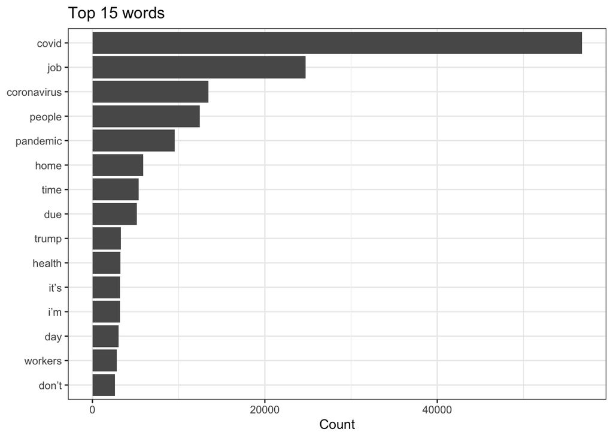

```r
tidy_data %>%
  count(word, sort = TRUE) %>%
  top_n(15) %>%
  mutate(word = fct_reorder(word, n)) %>%
  ggplot(aes(x = word, y = n)) +
  geom_col() +
  coord_flip() +
  theme_bw() +
  labs(title = "Top 15 words",
       x = NULL,
       y = "Count")
```

### 4.2.1 Removing custom *stop words*

```r
# add custom words to our stop_words list
keywords_remove <- tibble(word = c("coronavirus", "covid", "pandemic",
                                   "work", "job", "jobs"))

# add keywords_remove to the stop_words list
custom_stopwords <- tidytext::stop_words %>%
                     bind_rows(keywords_remove)

tidy_data <- tidy_data %>%

  # remove custom_stopwords
  anti_join(custom_stopwords, by = "word")

# clean up the environment by deleting the custom words related objects
rm(keywords_remove, custom_stopwords)
```

#### 4.2.1.1 Visualizing word frequency without custom stopwords

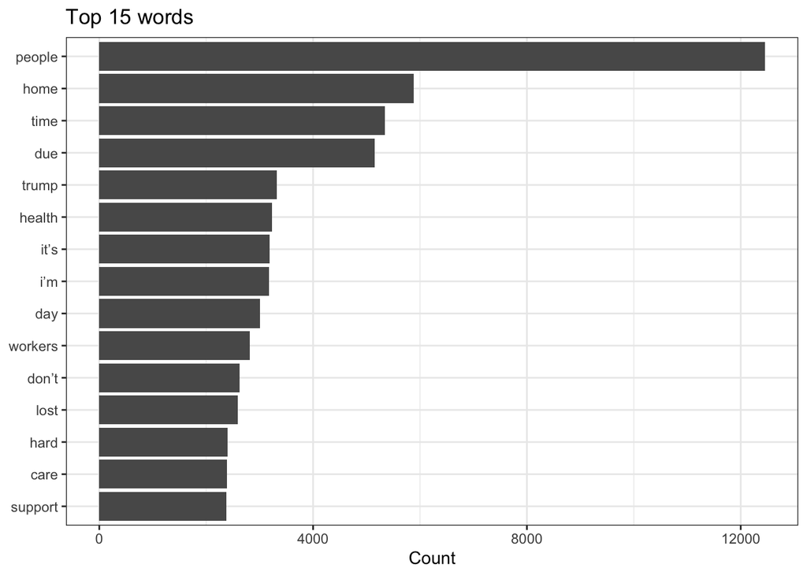

```r
tidy_data %>%
  count(word, sort = TRUE) %>%
  top_n(15) %>%
  mutate(word = fct_reorder(word, n)) %>%
  ggplot(aes(x = word, y = n)) +
  geom_col() +
  coord_flip() +
  theme_bw() +
  labs(title = "Top 15 words",
       x = NULL,
       y = "Count")
```

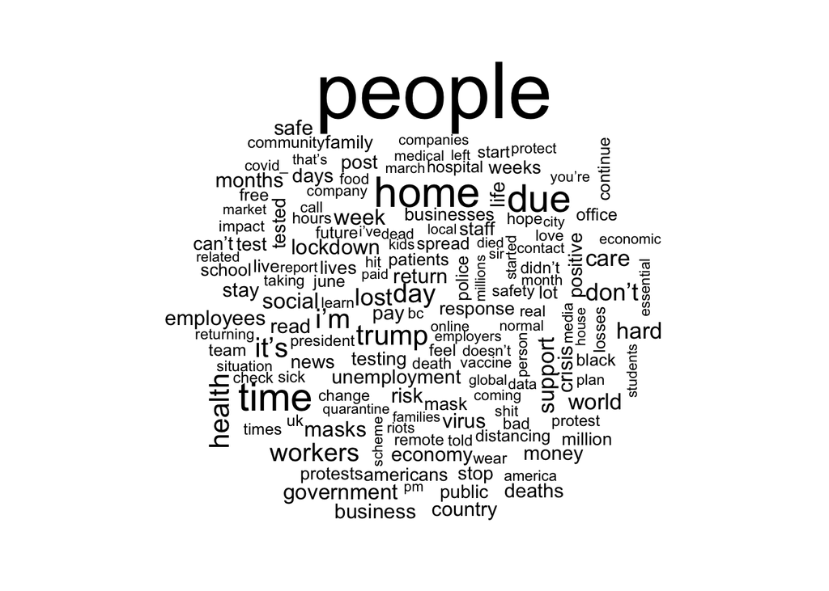

```r
wordcloud <- tidy_data %>%
  count(word) %>%
  with(wordcloud(word, n, max.words = 150))
```

```r
wordcloud
```

## 4.3 Loading the sentiment lexicons

In order for us to access different lexicons, we must ensure we have the `textdata` package installed. We will then be able to download, among others, the `Bing`, `Afinn`, and `nrc` lexicons. These are unigram lexicons and evaluate terms in different manners.

### 4.3.1 Bing

- `Bing` evaluates words based on a positive and negative polarity. It was first published in 2004 by Minqing Hu and Bing Liu.

```r
# save the Bing lexicon into lex_bing
lex_bing <- tidytext::get_sentiments("bing")

# number of terms in the Bing lexicon
count(lex_bing)
```

```
## # A tibble: 1 x 1
##       n
##   <int>
## 1  6786
```

```r
# Bing polarity type
lex_bing %>%
    count(sentiment)
```

```
## # A tibble: 2 x 2
##   sentiment     n
##   <chr>     <int>
## 1 negative   4781
## 2 positive   2005
```

### 4.3.2 Afinn

- `Afinn` on a scale from -5 to 5. It was published by Finn Ärup Nielsen in 2011.

```r
# save the Afinn lexicon into lex_afinn
lex_afinn <- tidytext::get_sentiments("afinn")

# number of terms in the Afinn lexicon
count(lex_afinn)
```

```
## # A tibble: 1 x 1
##       n
##   <int>
## 1  2477
```

```r
# Afinn polarity scale
lex_afinn %>%
    count(value)
```

```
## # A tibble: 11 x 2
##    value     n
##    <dbl> <int>
##  1    -5    16
##  2    -4    43
##  3    -3   264
##  4    -2   966
##  5    -1   309
##  6     0     1
##  7     1   208
##  8     2   448
##  9     3   172
## 10     4    45
## 11     5     5
```

### 4.3.3 NRC

- The `nrc` lexicon evaluates both on a polarity level (positive and negative) and is designed to identify eight human emotions (anger, anticipation, disgust, fear, joy, sadness, surprise, trust) in text. It was published by Saif Mohammad and Peter Turney in 2013 and it requires a licence for commercial use.

```r
# save the NRC lexicon into lex_nrc
lex_nrc <- tidytext::get_sentiments("nrc")

# number of terms in the NRC lexicon
count(lex_nrc)
```

```
## # A tibble: 1 x 1
##       n
##   <int>
## 1 13901
```

```r
# NRC polarity scale
lex_nrc %>%
    count(sentiment)
```

```
## # A tibble: 10 x 2
##    sentiment        n
##    <chr>        <int>
##  1 anger         1247
##  2 anticipation   839
##  3 disgust       1058
##  4 fear          1476
##  5 joy            689
##  6 negative      3324
##  7 positive      2312
##  8 sadness       1191
##  9 surprise       534
## 10 trust         1231
```

## 4.4 Applying sentiment analysis using the NRC lexicon

We will performing our sentiment analysis using the sentiment dictionaries by performing an `inner_join()`. In effect, we are merging the data with the lexicon.

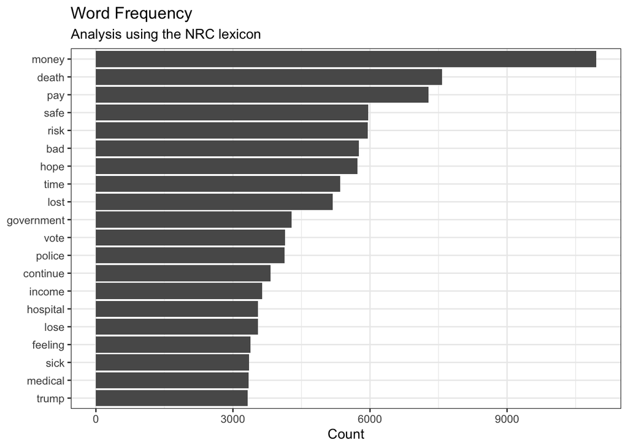

```r
sa_nrc <- tidy_data %>%
  inner_join(lex_nrc, by = "word")

sa_nrc %>%
  count(word, sort = TRUE) %>%
  mutate(word = fct_reorder(word, n)) %>%
  top_n(20) %>%
  ggplot(aes(x = word, y = n)) +
  geom_col() +
  coord_flip() +
  theme_bw() +
  labs(title = "Word Frequency",
       subtitle = "Analysis using the NRC lexicon",
       x = NULL,
       y = "Count")
```

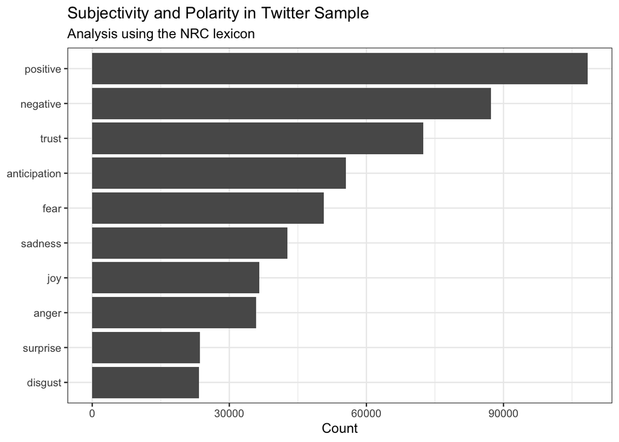

```r
sa_nrc %>%
  count(sentiment, sort = TRUE) %>%
  mutate(sentiment = fct_reorder(sentiment, n)) %>%
  ggplot(aes(x = sentiment, y = n)) +
  geom_col() +
  coord_flip() +
  theme_bw() +
  labs(title = "Subjectivity and Polarity in Twitter Sample",
       subtitle = "Analysis using the NRC lexicon",
       x = NULL,
       y = "Count")
```

Let us look at some examples of tweets that have been labeled *positive* and *negative*.

```r
head(data$text[sa_nrc$sentiment == "negative"])
```

```
## [1] "“the government should stop thinking its job is to keep everyone healthy and instead focus on protecting our rights,” says a post on the organization’s website. last time i checked, 'life' is the first of those 'unalienable rights.'"
## [2] "what is this crap? , dead from covid and still no plan. maybe you should actually do some work!!! #bunkerboy"
## [3] "he’s just mad because due to the covid, he has found out every parent in the country can do his job. yet he can’t do theirs"
## [4] "after the good work that gov cuomo did in new york for the coronavirus, i am horrified to hear him take a page out of trump's playbook concerning the violence of the new york police departments. i saw what they did it continues. cuomo denied it."
## [5] "rook fashion values our customers and their health greatly. we will continue to work to overcome this covid- pandemic as one with our staff and our customers."
## [6] "any employee residing in a covid- containment zone should be allowed to work from home and not attend office till the time the area is denotified and that period will not be counted as leave."
```

```r
head(data$text[sa_nrc$sentiment == "positive"])
```

```
## [1] "your comment was about getting job opportunities. record low unemployment means record numbers of people working...ie actually getting those job opportunities you mentioned. the economy was in th gear until covid slammed on the breaks. i’d blame that first and foremost"
## [2] "my husband has been back to work at major manuf’g plant for -/ weeks. maintenance guy told him yesterday, employee tested + for #covid another showing symptoms is awaiting results. no news from employer or public health. why? \U0001f92b can’t demonstrate safety now"
## [3] "dear president trump: grandma sortland here again. sir, we are senior folks at very high-risk regarding covid-. i lost my job because of it. haven't found another yet. we are desperate for a nd stimulus assistance for rent and prescriptions. help us, please!"
## [4] "so i’ve been pretty silent about it, but i did officially lose my job. due to cuts made at the company from the coronavirus pandemic. not sure if i want to be angry or relieved tho. that place sucked, but my newfound stress sucks too."
## [5] "reposted from mitsmr the coronavirus pandemic has led to a surge in virtual work. one of the unintended consequences of this switch to virtual work is the impact on employee relationships. by understanding how…"
## [6] "since isolation measures were first imposed in an effort to slow the spread of covid-, the u.s. economy has become a basket case. / of small businesses and /th of restaurants have closed. in american workers is out of a job and stocks climb on the tax payers dime"
```

## 4.5 Applying sentiment analysis using the Bing lexicon

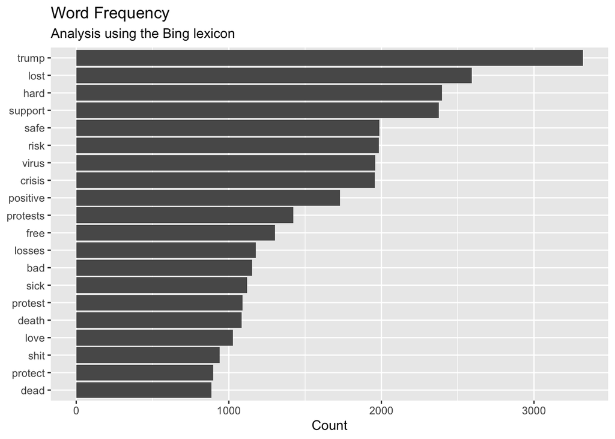

```r
sa_bing <- tidy_data %>%
  inner_join(lex_bing, by = "word")

sa_bing %>%
  count(word, sort = TRUE) %>%
  mutate(word = fct_reorder(word, n)) %>%
  top_n(20) %>%
  ggplot(aes(x = word, y = n)) +
  geom_col() +
  coord_flip() +
   labs(title = "Word Frequency",
       subtitle = "Analysis using the Bing lexicon",
       x = NULL,
       y = "Count")
```

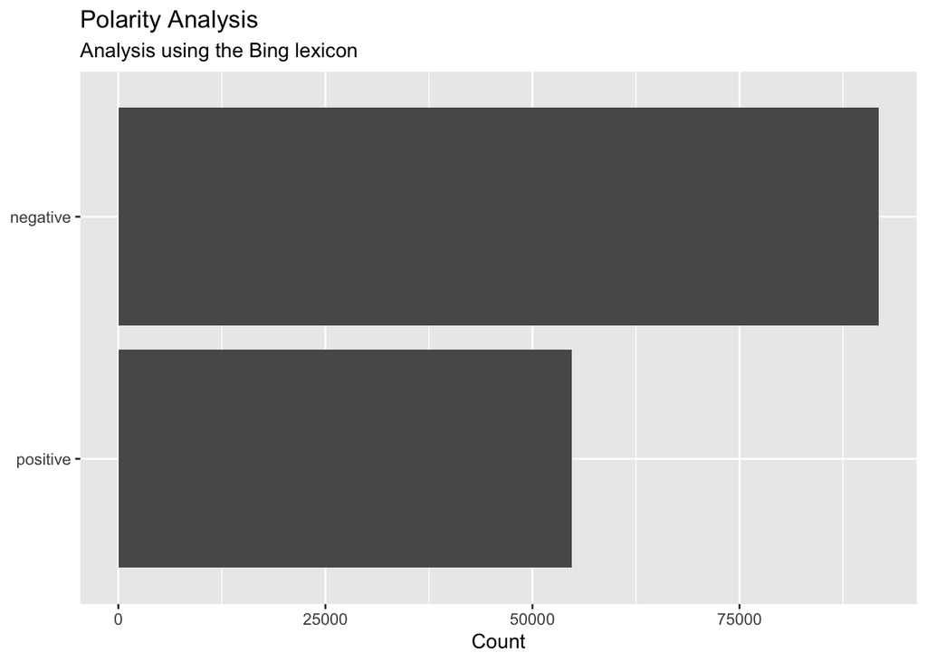

```r
sa_bing %>%
  count(sentiment, sort = TRUE) %>%
  mutate(sentiment = fct_reorder(sentiment, n)) %>%
  ggplot(aes(x = sentiment, y = n)) +
  geom_col() +
  coord_flip() +
  labs(title = "Polarity Analysis",
       subtitle = "Analysis using the Bing lexicon",
       x = NULL,
       y = "Count")
```

Some examples of negative and positive tweets:

```r
# positive tweets
data$text[sa_bing$sentiment == "positive"][500:509]
```

```
##  [1] "one of the most obvious things this david it won’t be long before the chinese (once they have sold us medical supplies) suddenly miraculously find a cure to sell to the world making £billions."
##  [2] "i can imagine. i lost a -day-old design job on march th due to covid- and recession fears and thanks to what can only be described as insanely bad luck, i apparently don't qualify for either unemployment or pandemic aid. i still apply on a weekly basis, but so far, nothing."
##  [3] "i hope this message finds you and your loved ones safe and healthy. it’s been about weeks since our industry went down due to covid- and i, as well as all of you, am sure ready to get back to work! but of course, we can’t do that until it is safe to do so. having all of our"
##  [4] "fema camps. everything was being prepared supposedly for the coronavirus. how convenient. don’t trust the media they all work together."
##  [5] "my friend arlo came to visit at work today! i haven’t seen him since the covid hit."
##  [6] "people wanted to go to work and church and got arrested because of covid just wks ago and now ppl are allowed to gather by the thousands and they are burning churches and businesses with no consequences."
##  [7] "pls work on this mr governor a better government should govern in the best process for the best productivity pls with interstate restrictions why there is still surge in the no of covid cases ? this a question you and the task force need to answer"
##  [8] "chief medical officer, chad krilich, m.d., thanks caregivers and physicians for their hard work and commitment over the past several months as they worked together to prepare and respond to covid-."
##  [9] "y’all must think i’m a fool if you think your sources of heart complications and coronavirus were the reason george floyd was killed. typical....someone should tell them their job ain’t that essential if their gonna twist the facts all the time."
## [10] "va backlog of claims grows to , as work stopped for coronavirus"
```

```r
# negative tweets
data$text[sa_bing$sentiment == "negative"][500:509]
```

```
##  [1] "#helpcovidheroes i am a nurse tech working in the er and also a student in nursing school taking online classes. my father passed away on may of last year so i’ve been supporting my mother and grandparents full-time. my mother lost her job due to the coronavirus pandemic as well"
##  [2] "\"however, i will say that i do feel that i agree with the people who say, ‘if it’s your job or your life, it should be your life that you pick.’ and i think that’s what black lives matter is doing — they’re picking life.”"
##  [3] "i give money monthly.....even though i had to close my small hair salon because of \"covid\" ....back at work and will give more as i can! \U0001f1fa\U0001f1f2\U0001f1fa\U0001f1f2\U0001f1fa\U0001f1f2"
##  [4] "joe biden regains election edge as trump job approval dives amid coronavirus crisis, protests: ibd/tipp poll via"
##  [5] "ok you opened up the state and now the covid cases are rising even hire, good job govenor moron!!!!"
##  [6] "go away mr doctor, who has not even completed his residency. stop self-promoting yourself and \"your\" team. how can we trust u? there are people out there who are actually helping with covid- and not bragging, just doing their job."
##  [7] "‘it took the pandemic to shake us up’: what covid- has taught us about the nature of the way we work, and what we must do to fix it for the safety and betterment of us all"
##  [8] "trump even got more votes in california than bernie this past primary. red wave coming and the dems know it. that's when the coronavirus got started up and then these planned riots. deep state still at work. wake up and see the light people."
##  [9] "coronavirus isn't what it was hyped up to be. trump needs to pull that unemployment stimulus money now so people get back to work. to much time on these idiots hands."
## [10] "pull the unemployment stimulus money now mr president. these people have to much time on their hands. coronavirus is bs for healthy americans. time for these ungrateful young people to go back to work asap."
```